# Multiple List Free Recall Example

Nicholas Maxwell, Erin Buchanan

2021-11-28

# Libraries and Data

Please see manuscript for a long description of the following data. We will load the example data, and you can use the `?` with the dataset name to learn more about the data. This example focuses on expanding the free recall options to include multiple or randomized lists by participant. You will need the data with a “list” or trial ID, as well as a matching answer key with the same ID.

```r
library(lrd)
data("multi_data")
head(multi_data)
```

```
#>   Sub.ID       List.Type
#> 1      1   Cat_Recall_L1
#> 2      1 AdHoc_Recall_L2
#> 3      1 Unrel_Recall_L3
#> 4      2 Unrel_Recall_L4
#> 5      2   Cat_Recall_L5
#> 6      2 AdHoc_Recall_L6
#>                                                             Response
#> 1     rosemary onionsalt chilli powder ginger gloves bayleaves curry
#> 2       yo-yo top sphere orb spiral satellite bicycle gear hurricane
#> 3                          bishop desert whale index canteen lantern
#> 4            canoe dentist vapor solar saloon baby farm nugget valve
#> 5              cheese cloth jersey denim tweed burlap sheepskin lace
#> 6 door chair desk table clogs cabinet ship ruler shelf pencil stairs
#>   List.Number
#> 1           1
#> 2           2
#> 3           3
#> 4           4
#> 5           5
#> 6           6
```

```r
#?multi_data

data("multi_answers")
head(multi_answers)
```

```
#>        List1     List2  List3   List4        List5
#> 1     NUTMEG  WINDMILL MANUAL   SOLAR      CHIFFON
#> 2    VANILLA   DREIDEL DESERT   CANOE       DENIUM
#> 3      THYME SATELLITE HELMET BLOSSOM CHEESE CLOTH
#> 4      CUMIN    SPIRAL  CANDY DENTIST       BURLAP
#> 5 ONION SALT   TORNADO  INDEX    MATH      WORSTED
#> 6     CHIVES  PINWHEEL ORPHAN   ACORN       ANGORA
#>           List6
#> 1          DOOR
#> 2        GAZEBO
#> 3         RULER
#> 4 ROCKING HORSE
#> 5         HOUSE
#> 6          BARN
```

```r
#?multi_answers

library(ggplot2)
library(reshape)
```

# Data Restructuring

The participant data should be in long format with each answer as one row of data. The participant ID will be repeated by participant, while the trial ID will be repeated by trial. You should use the `repeated` argument to indicate the information that denotes how the trials are repeated across participants. Note that in our example `List.Type` and `List.Number` contain the same information.

```r
DF_long <- arrange_data(data = multi_data,
      responses = "Response",
      sep = " ",
      id = "Sub.ID",
      repeated = "List.Number")
head(DF_long)
```

```
#>    response position Sub.ID List.Number
#> 1  rosemary        1      1           1
#> 2 onionsalt        2      1           1
#> 3    chilli        3      1           1
#> 4    powder        4      1           1
#> 5    ginger        5      1           1
#> 6    gloves        6      1           1
```

Next, we will restructure the answer key to have one column for the answers and one column for the list ID. We will also relabel the columns (since `reshape`’s output is vague using `variable` and `value`). Last, we need to make sure the list ID column matches the column in our participant data.

```r
multi_answers$position <- 1:nrow(multi_answers) #this column is only to reshape
answer_long <- melt(multi_answers,
                    measured = colnames(multi_answers),
                    id = "position")

#fix columns
colnames(answer_long) <- c("position", "List.ID", "Answer")

#match list id to participant data, which is only numbers
#list IDs can be characters or numbers
answer_long$List.ID <- gsub(pattern = "List",
                            replacement = "",
                            x = answer_long$List.ID)

head(answer_long)
```

```
#>   position List.ID     Answer
#> 1        1       1     NUTMEG
#> 2        2       1    VANILLA
#> 3        3       1      THYME
#> 4        4       1      CUMIN
#> 5        5       1 ONION SALT
#> 6        6       1     CHIVES
```

# Data Cleanup

Scoring in `lrd` is case sensitive, so we will use `tolower()` to lower case all correct answers and participant answers. In this particular example, all the spaces from the participant answers were removed, so we will also remove them from the answer key.

```r
DF_long$response <- tolower(DF_long$response)
answer_long$Answer <- tolower(answer_long$Answer)
answer_long$Answer <- gsub(" ", "", answer_long$Answer)

head(DF_long)
```

```
#>    response position Sub.ID List.Number
#> 1  rosemary        1      1           1
#> 2 onionsalt        2      1           1
#> 3    chilli        3      1           1
#> 4    powder        4      1           1
#> 5    ginger        5      1           1
#> 6    gloves        6      1           1
```

```r
head(answer_long)
```

```
#>   position List.ID    Answer
#> 1        1       1    nutmeg
#> 2        2       1   vanilla
#> 3        3       1     thyme
#> 4        4       1     cumin
#> 5        5       1 onionsalt
#> 6        6       1    chives
```

# Score the Data

You should define the following:

- data = dataframe of participant responses
- responses = column name of the participant answers
- key = column name of the answer key
- key.trial = list ID denoting the different lists participants completed
- id = column name of the participant id number
- id.trial = column name of the list ID within the participant data (this can be the same column as key.trial)
- cutoff = the Levenshtein distance value you want to use for scoring (0 no changes exactly the same, higher numbers allow more variance in the word)
- flag = calculate z scores for outliers (TRUE/FALSE)
- group.by = column name(s) for grouping variables

```r
free_output <- prop_correct_multiple(data = DF_long,
                                 responses = "response",
                                 key = answer_long$Answer,
                                 key.trial = answer_long$List.ID,
                                 id = "Sub.ID",
                                 id.trial = "List.Number",
                                 cutoff = 1,
                                 flag = TRUE)


str(free_output)
```

```
#> List of 2
#>  $ DF_Scored     :'data.frame':  117 obs. of  6 variables:
#>   ..$ Responses  : chr [1:117] "basil" "basil" "bayleaves" "bayleaves" ...
#>   ..$ position   : chr [1:117] "8" "7" "7" "8" ...
#>   ..$ Sub.ID     : chr [1:117] "5" "3" "1" "3" ...
#>   ..$ List.Number: chr [1:117] "1" "1" "1" "1" ...
#>   ..$ Answer     : chr [1:117] "basil" "basil" "bayleaves" "bayleaves" ...
#>   ..$ Scored     : num [1:117] 1 1 1 1 1 1 1 0 1 1 ...
#>  $ DF_Participant:'data.frame':  14 obs. of  4 variables:
#>   ..$ Sub.ID             : chr [1:14] "1" "3" "5" "1" ...
#>   ..$ Proportion.Correct : num [1:14] 0.3 0.45 0.45 0.45 0.45 0.55 0.3 0.35 0.35 0.35 ...
#>   ..$ List.Number        : chr [1:14] "1" "1" "1" "2" ...
#>   ..$ Z.Score.Participant: num [1:14, 1] -1.155 0.577 0.577 -0.577 -0.577 ...
#>   .. ..- attr(*, "dimnames")=List of 2
#>   .. .. ..$ : NULL
#>   .. .. ..$ : NULL
```

# Output

We can use `DF_Scored` to see the original dataframe with our new scored column - also to check if our answer key and participant answers matched up correctly! The `DF_Participant` can be used to view a participant level summary of the data. Last, if a grouping variable is used, we can use `DF_Group` to see that output.

```r
#Overall
free_output$DF_Scored
```

```
#>       Responses position Sub.ID List.Number
#> 1         basil        8      5           1
#> 2         basil        7      3           1
#> 3     bayleaves        7      1           1
#> 4     bayleaves        8      3           1
#> 5     bayleaves        3      5           1
#> 6    celeryseed        1      5           1
#> 7   chilipowder        6      3           1
#> 8        chilli        3      1           1
#> 9         chyme        3      3           1
#> 10       cloves        9      3           1
#> 11        cumin        7      5           1
#> 12        curry        6      5           1
#> 13        curry        8      1           1
#> 14       ginger        5      1           1
```

[output cut: 221 more lines]

```r
#Participant
free_output$DF_Participant
```

```
#>    Sub.ID Proportion.Correct List.Number
#> 1       1               0.30           1
#> 2       3               0.45           1
#> 3       5               0.45           1
#> 4       1               0.45           2
#> 5       3               0.45           2
#> 6       5               0.55           2
#> 7       1               0.30           3
#> 8       3               0.35           3
#> 9       2               0.35           4
#> 10      4               0.35           4
#> 11      2               0.30           5
#> 12      4               0.00           5
#> 13      2               0.55           6
#> 14      4               0.25           6
#>    Z.Score.Participant
#> 1           -1.1547005
#> 2            0.5773503
#> 3            0.5773503
#> 4           -0.5773503
#> 5           -0.5773503
#> 6            1.1547005
#> 7           -0.7071068
#> 8            0.7071068
#> 9                  NaN
#> 10                 NaN
#> 11           0.7071068
#> 12          -0.7071068
#> 13           0.7071068
#> 14          -0.7071068
```

```r
#Group
#free_output$DF_Group
```

# Other Possible Calculations

## Serial Position

This function prepares the data for a serial position curve analysis or visualization. Please note, it assumes you are using the output from above, but any output with these columns would work fine. The arguments are roughly the same as the overall scoring function. We’ve also included some `ggplot2` code as an example to help show how you might use our output for plotting. `List.ID` indicates the list identifier for examining differences in responses between lists.

```r
serial_output <- serial_position_multiple(data = free_output$DF_Scored,
                                position = "position",
                                answer = "Answer",
                                key = answer_long$Answer,
                                key.trial = answer_long$List.ID,
                                scored = "Scored",
                                id.trial = "List.Number")

head(serial_output)
```

```
#>   Tested.Position Freq Proportion.Correct        SE
#> 1               1    0          0.0000000 0.0000000
#> 2               3    0          0.0000000 0.0000000
#> 3               4    0          0.0000000 0.0000000
#> 4               5    1          0.3333333 0.2721655
#> 5               7    1          0.3333333 0.2721655
#> 6               8    0          0.0000000 0.0000000
#>   List.ID
#> 1       1
#> 2       1
#> 3       1
#> 4       1
#> 5       1
#> 6       1
```

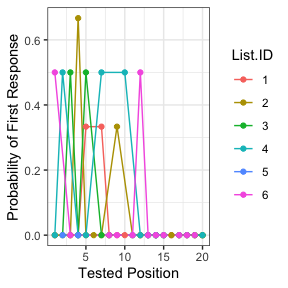

```r
ggplot(serial_output, aes(Tested.Position, Proportion.Correct, color = List.ID)) +
  geom_line() +
  geom_point() +
  xlab("Tested Position") +
  ylab("Probability of First Response") +
  theme_bw()
```

## Conditional Response Probability

Conditional response probability is the likelihood of answers given the current answer set. Therefore, the column participant_lags represents the lag between the written and tested position (e.g., *chair* was listed second, which represents a lag of -6 from spot number 8 on the answer key list). The column `Freq` represents the frequency of the lags between listed and shown position, while the `Possible.Freq` column indicates the number of times that frequency could occur given each answer listed (e.g., given the current answer, a tally of the possible lags that could still occur). The `CRP` column calculates the conditional response probability, or the frequency column divided by the possible frequencies of lags.

```r
crp_output <- crp_multiple(data = free_output$DF_Scored,
                  key = answer_long$Answer,
                  position = "position",
                  scored = "Scored",
                  answer = "Answer",
                  id = "Sub.ID",
                  key.trial = answer_long$List.ID,
                  id.trial = "List.Number")

head(crp_output)
```

```
#>   Sub.ID participant_lags Freq Possible.Freq
#> 1      1              -19    0             0
#> 2      1              -18    0             0
#> 3      1              -17    0             0
#> 4      1              -16    0             0
#> 5      1              -15    1             2
#> 6      1              -14    0             0
#>   List.Number CRP
#> 1           1 0.0
#> 2           1 0.0
#> 3           1 0.0
#> 4           1 0.0
#> 5           1 0.5
#> 6           1 0.0
```

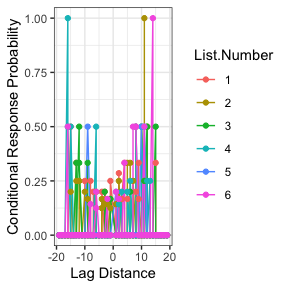

```r
crp_output$participant_lags <- as.numeric(as.character(crp_output$participant_lags))

ggplot(crp_output, aes(participant_lags, CRP, color = List.Number)) +
  geom_line() +
  geom_point() +
  xlab("Lag Distance") +
  ylab("Conditional Response Probability") +
  theme_bw()
```

## Probability of First Response

Participant answers are first filtered for their first response, and these are matched to the original order on the answer key list (`Tested.Position`). Then the frequency (`Freq`) of each of those answers is tallied and divided by the number of participants overall or by group if the `group.by` argument is included (`pfr`).

```r
pfr_output <- pfr_multiple(data = free_output$DF_Scored,
                  key = answer_long$Answer,
                  position = "position",
                  scored = "Scored",
                  answer = "Answer",
                  id = "Sub.ID",
                  key.trial = answer_long$List.ID,
                  id.trial = "List.Number")

head(pfr_output)
```

```
#>   Tested.Position Freq       pfr List.ID
#> 1              12    1 0.3333333       1
#> 2              14    1 0.3333333       1
#> 3              20    1 0.3333333       1
#> 4               6    1 0.3333333       2
#> 5              13    1 0.3333333       2
#> 6              14    1 0.3333333       2
```

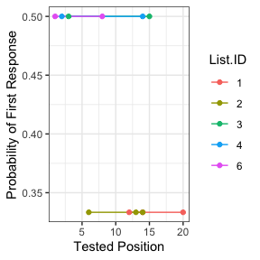

```r
pfr_output$Tested.Position <- as.numeric(as.character(pfr_output$Tested.Position))

ggplot(pfr_output, aes(Tested.Position, pfr, color = List.ID)) +
  geom_line() +
  geom_point() +
  xlab("Tested Position") +
  ylab("Probability of First Response") +
  theme_bw()
```